# C01 — Od rekordu do wyniku: RStudio i własna przestrzeń pracy

Zarządzanie informacją — ćwiczenie i zadanie Z01 — 2026/27

2026/27

# Początek pracy na ćwiczeniu C01

Otwórz swój projekt kursu w Posit Cloud albo RStudio na własnym komputerze; pakiet kursu `badaniaZI` jest w nim zainstalowany. Dwa polecenia z następnego bloku wpisujesz w konsoli RStudio, czyli w dolnym panelu ze znakiem `>`; w miejsce `TWOJE_ID` wpisz swoje ID, a w miejsce `Imię Nazwisko` — swoje imię i nazwisko. Dokument PDF zawiera dwa polecenia jako tekst instrukcji.

```r
library(badaniaZI)
rozpocznij_zajecia("C01", id_studenta = "TWOJE_ID", student = "Imię Nazwisko")
```

Sprawdź w komunikacie ID oraz imię i nazwisko. Przy pierwszym starcie funkcja tworzy folder `moje-badania` i zapisuje w nim oba dane; pliki pracy zachowują je także po zamknięciu projektu, a imię i nazwisko trafiają do nazwy oddawanego pliku.

Funkcja `rozpocznij_zajecia()` otwiera własny plik `zadanie.Rmd`, zapamiętuje katalog pracy i kopiuje do folderu `moje-badania/materialy` wersję HTML i PDF ćwiczenia oraz rubrykę zadania. Pracuj w otwartym pliku `zadanie.Rmd` do końca zajęć. Najpierw uruchom blok `przygotowanie`, a potem kolejne części LEARN i CHALLENGE. Przy problemie poproś prowadzącego o pomoc; plik pracy i własne ID pozostają bez zmian.

Plik ćwiczenia łączy tekst z blokami kodu R, nazywanymi chunkami. Chunk zaczyna się linią z trzema znakami `` ``` `` i nazwą w nawiasie klamrowym; uruchamiasz go zieloną strzałką w prawym górnym rogu bloku albo skrótem Ctrl+Shift+Enter. Pierwszy chunk, `przygotowanie`, wczytuje gotowy skrypt `analiza.R`. Skrypt tworzy małą tabelę `mini` (sześć osób), tabelę `portal` (osiem osób), dane S02 po przygotowaniu (148 osób) oraz funkcje wyświetlające tabele i wykresy; działa bez zmian.

Każdy kolejny chunk zapisuje wynik funkcji w obiekcie o opisowej nazwie, a polecenie `print()` wyświetla obiekt w dokumencie. Funkcja `pokaz_tabele(tabela, tytuł)` drukuje tabelę z tytułem w PDF i HTML, a `pokaz_wykres(wykres)` drukuje wykres.

# Po co otwieramy tabelę

Biblioteka chce wiedzieć, dlaczego część osób ma trudności ze znalezieniem dokumentu w katalogu. Odpowiedź wymaga informacji o konkretnej osobie: co próbowała zrobić, ile trwało zadanie, czy znalazła właściwy dokument i jak ocenia katalog. Cztery informacje uzupełniają się i czasem prowadzą do różnych ocen sytuacji.

Wyobraź sobie dwie osoby. Pierwsza po dwóch minutach wybiera niewłaściwy rekord i jest przekonana, że odniosła sukces. Druga potrzebuje dziewięciu minut, odnajduje właściwe wydanie i sprawdza lokalizację. Zdanie „pierwsza osoba lepiej wyszukuje, bo jest szybsza” pomija poprawność. Zdanie „druga lepiej ocenia swoje umiejętności, więc musi być skuteczniejsza” myli deklarację z obserwacją. Od pierwszych zajęć zatrzymujemy się przed przeskokiem od liczby do oceny osoby.

Rezultatem zajęć jest krótka, własna odpowiedź oparta na odczytanym wyniku. R wykonuje przygotowane obliczenia, a Twoim zadaniem jest odczyt: rozpoznanie obserwacji, zmiennej, jednostki i mianownika oraz sprawdzenie, czy zdanie wynika z tabeli.

W części LEARN pracujemy na małej tabeli sześciu osób korzystających z katalogu. Część CHALLENGE dotyczy ośmiu innych osób szukających informacji w portalu studenckim. Oba zbiory są syntetyczne i odrębne: sposób rozumowania przenosisz z LEARN do CHALLENGE, a liczby odczytujesz z tabel portalu. Rozwinięcie po części obowiązkowej zawiera podgląd zbioru S02 — syntetycznej ankiety po zadaniu wyszukiwawczym połączonej z obserwacją czasu i powodzenia, która towarzyszy całemu kursowi.

## Jak pracować z ćwiczeniem C01

Przeznacz około 5 minut na odtworzenie pracy, 30 minut na pięć bloków LEARN, 50 minut na pięć zadań CHALLENGE i 5 minut na zapis oraz oddanie. LEARN to część z gotowymi przykładami i wzorcową interpretacją: uruchamiasz przykład i porównujesz wynik z opisem. CHALLENGE to część z pięcioma odpowiedziami, które piszesz samodzielnie w oznaczonych miejscach, poza blokami kodu. Gdy odczyt wyniku sprawia trudność, pytasz prowadzącego.

Wszystkie odpowiedzi zapisujesz w pliku `zadanie.Rmd`. Rozwinięcia po CHALLENGE służą powtórce i pozostają poza oceną. PDF przedstawia wyniki oraz Twój tekst i powstaje z zapisanego pliku podczas oddania.

Bloki LEARN kończą się **wzorcem zapisu** — przykładowym zdaniem, które opisuje wynik według standardu APA. Zadania CHALLENGE stosują te same wzorce do danych portalu: każde zadanie ma blok R z kompletem potrzebnych liczb, wskazówki odczytu z wzorem zdania, listę elementów akapitu i wyróżnione pole na Twój akapit.

Przy każdym bloku najpierw przeczytaj dwa–trzy zdania wyjaśnienia. Przed uruchomieniem przewidź rodzaj wyniku: jedną liczbę, kolumnę, tabelę czy wykres. Po wykonaniu porównaj przewidywanie z wynikiem. Porównanie przewidywania z wynikiem jest początkiem rozumowania statystycznego, także przy prostym działaniu arytmetycznym.

# Warsztat: projekt, skrypt i wynik

## R, RStudio i pakiet kursu

R jest programem wykonującym polecenia. RStudio jest środowiskiem do edycji plików, uruchamiania kodu i oglądania wyników. Pakiet `badaniaZI` dostarcza danych, materiałów i gotowych funkcji kursowych. Relacja trzech elementów przypomina pracownię, narzędzia i przygotowaną procedurę pomiaru.

Konsola wykonuje polecenie od razu. Edytor przechowuje tekst skryptu, który da się zapisać i uruchomić ponownie. Panel Environment wymienia obiekty istniejące w bieżącej sesji. Obiekty w panelu Environment istnieją do końca sesji; trwały zapis analizy zawierają pliki `.R` i `.Rmd`.

| Element | Co zawiera? | Do czego wracasz po zajęciach? |
| --- | --- | --- |
| Projekt `.Rproj` | Zapis ustawień przestrzeni pracy | Nie trzeba go otwierać; pakiet sam odnajduje przestrzeń pracy |
| Skrypt `.R` | Polecenia i funkcje | Uruchamiasz analizę od początku |
| Dokument `.Rmd` | Polecenia, bloki R i własny tekst | Uruchamiasz chunk i piszesz odpowiedź pod wynikiem |
| Plik `.md` | Pomocniczą dokumentację, np. instrukcję | Sprawdzasz zasady; odpowiedzi zapisujesz w Rmd |
| Tabela `.csv` | Zapisane dane lub wynik | Sprawdzasz źródło liczby |
| PDF/HTML | Czytelną wersję opracowania | Porównujesz tekst, tabelę i wykres |

Funkcja `rozpocznij_zajecia()` otwiera roboczy `zadanie.Rmd` w bieżącej sesji i zapamiętuje jego przestrzeń. Pliku `.Rproj` nie trzeba otwierać: pakiet odnajduje przestrzeń pracy w bieżącym folderze. Przestrzeń ćwiczeń służy zadaniom Z01–Z10; projekt indywidualny rozpoczyna się na ćwiczeniu C09 (Warsztat projektu). Pakiet rozpoznaje ścieżki plików automatycznie. Sprawdź nazwę oraz ID pracy w komunikacie startowym.

Dokument PDF przedstawia stan obliczeń z chwili jego budowania; po zmianie parametru w skrypcie aktualny wynik daje nowy render. Plik źródłowy `.Rmd` łączy treść z analizą, a osobny `.R` przechowuje przygotowane obliczenia. Podział na dwa pliki pozwala skupić się na znaczeniu wyniku i zachować możliwość jego odtworzenia.

# LEARN 1: co opisuje pojedynczy wiersz

Tabela `mini` ma sześć wierszy (osoby u01–u06) i cztery kolumny: `id`, `grupa`, `czas_min` i `powodzenie`. Każdy wiersz przedstawia jedną osobę i jedno zadanie. Zapis `NA` oznacza brak pomiaru: wartość pozostaje nieznana.

```r
obserwacje <- pokaz_tabele(mini, "Sześć osób wykonujących zadanie")
print(obserwacje)
```

**Sześć osób wykonujących zadanie**

| id | grupa | czas_min | powodzenie |
| --- | --- | --- | --- |
| u01 | nowi | 6 | 1 |
| u02 | nowi | 8 | 1 |
| u03 | doświadczeni | 12 | 0 |
| u04 | nowi | NA | NA |
| u05 | doświadczeni | 9 | 1 |
| u06 | nowi | 5 | 0 |

Przeczytaj trzeci wiersz pełnym zdaniem: osoba u03 należy do grupy doświadczonych, zarejestrowany czas wynosi 12 minut, a zadanie zakończyło się niepowodzeniem. Kod 0 w kolumnie `powodzenie` oznacza niepowodzenie zadania, zgodnie z definicją kolumny.

Wiersz u04 zawiera grupę osoby, a czas i wynik zadania są nieznane. Przyczyną braku mogła być awaria rejestracji albo przerwanie pomiaru; wybór wyjaśnienia wymaga protokołu obserwacji.

Funkcja `odczyt_rekordu()` obraca wybrany rekord do postaci „pole — wartość”. Obrócony rekord oddziela nazwę zmiennej od jej wartości dla konkretnej osoby. Aby porównać oba przypadki, zmień wyłącznie numer z 3 na 4.

```r
osoba <- odczyt_rekordu(mini, numer = 3)
print(osoba)
```

**Odczyt jednej osoby**

| pole | wartosc |
| --- | --- |
| id | u03 |
| grupa | doświadczeni |
| czas_min | 12 |
| powodzenie | 0 |

**Pytanie kontrolne:** ilu badanych opisuje jeden wiersz z czterema kolumnami? Jednego: kolumny opisują różne informacje o tej samej osobie. Podobnie sześć kliknięć jednej osoby to sześć zdarzeń jednej jednostki analizy.

W rzeczywistym badaniu jeden wiersz oznacza osobę, zadanie, sesję albo zdarzenie. Zdanie „mam 150 obserwacji” wymaga więc dopowiedzenia jednostki. Zbiór S02 ma 150 rekordów, w tym dwa identyczne duplikaty; po ich usunięciu 148 wierszy opisuje 148 osób.

## Słownik małej tabeli

Definicję pomiaru podaje słownik. W tabeli `mini` czas zapisuje obserwator w minutach, a powodzenie oznacza zgodność znalezionego dokumentu z poleceniem. Grupa doświadczenia i identyfikator opisują przynależność i tożsamość rekordu.

```r
slownik <- slownik_obserwacji()
print(slownik)
```

**Definicje czterech kolumn**

| kolumna | znaczenie | skala |
| --- | --- | --- |
| id | Identyfikator osoby | identyfikator |
| grupa | Wcześniejsze doświadczenie z katalogiem | nominalna |
| czas_min | Czas obserwowanego zadania [min] | ilorazowa |
| powodzenie | 0 = niepowodzenie, 1 = powodzenie | nominalna |

Przynależność do grupy doświadczonych opisuje osobę u03, a przyczynę niepowodzenia wyjaśnia protokół zadania. Opis obserwacji zachowuje granicę między wynikiem zadania a diagnozą cech osoby.

**Wzorzec zapisu rekordu.** Zdanie o jednej osobie podaje identyfikator, cechę osoby, wartość z jednostką i znaczenie kodu:

> Osoba u03 (grupa doświadczonych) wykonywała zadanie przez 12 min i zakończyła je niepowodzeniem (kod 0).

# LEARN 2: obiekt i wartość

Obiekt jest nazwanym wynikiem przechowywanym w sesji R. Skrypt `analiza.R` utworzył obiekt `czasy` z kolumną czasu tabeli `mini`. Wpisanie nazwy obiektu wyświetla wartości przygotowane w skrypcie.

Uruchom następny blok i odczytaj kolejność liczb. Znacznik `[1]` na początku wydruku podaje pozycję pierwszego wyświetlanego elementu.

```r
print(czasy)
```

```
## [1]  6  8 12 NA  9  5
```

Wektor przechowuje serię wartości jednego rodzaju. Wektor `czasy` ma sześć miejsc, w tym jedno brakujące: długość wektora wynosi 6, a liczba zmierzonych czasów 5.

Następny blok wybiera trzeci element wektora oraz odpowiadającą mu komórkę tabeli. Oba polecenia zwracają 12. Kwadratowy nawias oznacza wybór, a przecinek w nawiasie tabeli rozdziela wskazanie wiersza od wskazania kolumny.

```r
czas_z_wektora <- czasy[3]
print(czas_z_wektora)
```

```
## [1] 12
```

```r
czas_z_tabeli <- mini[3, "czas_min"]
print(czas_z_tabeli)
```

```
## [1] 12
```

Pierwsze polecenie oznacza „trzeci czas”, drugie „czas w trzecim wierszu tabeli”. Po posortowaniu tabeli trzeci wiersz może dotyczyć innej osoby, więc identyfikator i numer wiersza pełnią różne role. Przy odsyłaniu do konkretnego rekordu używamy identyfikatora.

Znak dolara wybiera kolumnę po nazwie. Cudzysłów służy zapisaniu tekstu, a wielkość liter w nazwie ma znaczenie. Literówka w nazwie przerywa wykonanie polecenia, a komunikat błędu wskazuje nazwę lub strukturę do sprawdzenia.

Dwa kolejne polecenia wyświetlają serię czasów i serię etykiet grup. Średnia ma sens dla serii czasów; seria etykiet grup wymaga liczebności kategorii.

```r
print(mini$czas_min)
```

```
## [1]  6  8 12 NA  9  5
```

```r
print(mini$grupa)
```

```
## [1] "nowi"         "nowi"         "doświadczeni" "nowi"         "doświadczeni"
## [6] "nowi"
```

Znaki `[ ]`, `$` i `" "` pozwalają rozpoznać, z której części tabeli pochodzi liczba. Gotowy skrypt ukrywa szczegóły obliczeń i jawnie nazywa ich wejście.

## Klasa w R i skala pomiaru

R przechowuje liczby, teksty i wartości logiczne w różnych klasach. Funkcja `class()` zwraca klasę obiektu: `numeric` dla liczb, `character` dla tekstu, `logical` dla wartości prawda i fałsz. Klasę techniczną uzupełnia słownik: słownik mówi, czy liczba jest czasem, kodem kategorii czy identyfikatorem.

Porównaj klasę kolumny czasu i klasę etykiet grup. Następnie sprawdź kolumnę powodzenia. Kolumna `powodzenie` ma klasę `numeric` i skalę nominalną z dwiema kategoriami wyniku.

```r
print(class(mini$czas_min))
```

```
## [1] "numeric"
```

```r
print(class(mini$grupa))
```

```
## [1] "character"
```

```r
print(class(mini$powodzenie))
```

```
## [1] "numeric"
```

Średnia ma sens dla kodu 0/1, bo suma kodów równa się liczbie jedynek, a średnia — proporcji jedynek. Kanał kontaktu zapisany jedną kolumną z kodami 1–4 (1 = strona WWW, 2 = e-mail, 3 = media społecznościowe, 4 = kontakt bezpośredni) opisuje się liczebnością każdego kodu, bo średnia kodów zmienia się razem z umowną numeracją kategorii. S02 zapisuje kanały w czterech kolumnach 0/1, więc średnia każdej kolumny kanału jest odsetkiem osób wybierających dany kanał.

W arkuszu kalkulacyjnym liczba zapisana jako tekst wygląda prawie tak samo jak liczba numeryczna, a R odmawia wtedy uśrednienia. Ćwiczenie C02 (Surowy eksport) sprawdza import liczb z przecinkiem dziesiętnym. Na C01 wystarczy zasada: przed interpretacją wyniku sprawdź, czy program odczytał kolumnę zgodnie ze słownikiem.

| Widziany zapis | Możliwy sens | Informacja do sprawdzenia |
| --- | --- | --- |
| 12 | Dwanaście minut | Jednostka i sposób pomiaru czasu |
| „12” | Tekst zawierający cyfry | Czy import poprawnie rozpoznał liczbę |
| 1 | Powodzenie | Kodowanie 0/1 i definicja sukcesu |
| 3 | Środkowa kategoria odpowiedzi | Dokładne brzmienie skali |
| NA | Brak wartości | Czy pomiar wykonano, czy zapisano |
| u03 | Identyfikator | Jaką jednostkę oznacza identyfikator |

# LEARN 3: brak danych zmienia mianownik

Mianownik odpowiada na pytanie „spośród ilu?”. Dla średniego czasu mianownikiem jest liczba ważnych pomiarów czasu, a dla odsetka powodzeń liczba znanych wyników zadania. Całkowita liczba wierszy opisuje plik; mianownik każdej miary to liczba ważnych wartości jej zmiennej.

Funkcja `mianowniki_obserwacji()` liczy osobno rekordy, ważne wartości i braki dla czasu oraz powodzenia. W tabeli `mini` obie zmienne mają po 6 rekordów, 5 ważnych wartości i 1 brak; w rzeczywistym zbiorze liczebności zmiennych bywają różne.

```r
liczebnosci <- mianowniki_obserwacji(mini)
print(liczebnosci)
```

**Czas**

| zmienna | rekordy | wazne | braki |
| --- | --- | --- | --- |
| czas_min | 6 | 5 | 1 |

**Powodzenie**

| zmienna | rekordy | wazne | braki |
| --- | --- | --- | --- |
| powodzenie | 6 | 5 | 1 |

Sześć rekordów zawiera pięć ważnych czasów o sumie 40 minut. Średnia wśród zmierzonych czasów wynosi $40/5=8$ minut. Dzielenie przez sześć potraktowałoby brak tak, jakby wnosił zero do sumy i jedną osobę do mianownika:

$$\bar{x}_{\text{z zerem}}=\frac{\sum x_i + 0}{n+m}=\bar{x}\cdot\frac{n}{n+m}=8\cdot\frac{5}{6}\approx 6{,}67 \text{ minuty},$$

gdzie $n=5$ to liczba ważnych pomiarów, a $m=1$ liczba braków zastąpionych zerem. Tabela „Brak a wymyślony pomiar zerowy” zestawia obie średnie: 8 minut i 6,67 minuty przy tej samej sumie 40 minut.

```r
porownanie <- pokaz_tabele(kontrola_braku, "Brak a wymyślony pomiar zerowy")
print(porownanie)
```

**Brak a wymyślony pomiar zerowy**

| postepowanie | suma_min | mianownik | srednia_min |
| --- | --- | --- | --- |
| Pięć zmierzonych czasów | 40 | 5 | 8,000 |
| Brak błędnie zastąpiony zerem | 40 | 6 | 6,667 |

Różnica 8 minut wobec 6,67 minuty wynika wyłącznie z reguły traktowania braku. Średnia 8 minut dotyczy osób z ważnym pomiarem. Jeśli pomiary przerywano w najtrudniejszych zadaniach, zmierzone osoby reprezentują łatwiejsze próby, więc poprawny rachunek wymaga także wiedzy o procesie powstawania braków.

**Wzorzec zapisu średniej przy braku (APA).** Symbol średniej *M* i liczba ważnych pomiarów *n* stoją w zdaniu razem z informacją o braku:

> Średni czas wyszukiwania wyniósł *M* = 8,00 min (*n* = 5); czas jednej z sześciu osób pozostaje nieznany.

## Czytamy pierwszy wzór

$$\bar{x}=\frac{\sum_{i=1}^{n}x_i}{n}.$$

Czytamy: „średnia to suma ważnych wartości podzielona przez ich liczbę”. Indeks $i$ numeruje składniki sumy. We wzorze $n$ obejmuje pięć zmierzonych czasów. Sumę można też zapisać wyłącznie po indeksach z ważnymi wartościami; sens mianownika pozostaje ten sam.

| Symbol | Jak nazwać? | Znaczenie w tabeli `mini` | Jednostka |
| --- | --- | --- | --- |
| $x_i$ | i-ty pomiar | Czas jednej osoby | min |
| $\sum x_i$ | suma pomiarów | Łącznie 40 minut | min |
| $n$ | liczba ważnych pomiarów | Pięć zarejestrowanych czasów | osoby |
| $\bar{x}$ | średnia w próbie | Osiem minut na ważny pomiar | min |
| $N$ | liczebność określonego zbioru | Liczba wymagająca nazwania zbioru | osoby lub rekordy |

Litery $N$ i $n$ bywają w publikacjach używane niejednolicie, więc mianownik rozpoznajemy z definicji w opisie metody lub w podpisie tabeli. Na kolejnych zajęciach podobnie czytamy $N$ kompletnych par i liczebności dwóch grup.

Funkcja `mean()` oblicza średnią. Argument `na.rm = TRUE` pomija brakujące wartości w bieżącym obliczeniu; tabela pozostaje bez zmian.

```r
suma_minut <- sum(czasy, na.rm = TRUE)
print(suma_minut)
```

```
## [1] 40
```

```r
srednia_minut <- mean(czasy, na.rm = TRUE)
print(srednia_minut)
```

```
## [1] 8
```

Po zmianie jednostki z minut na sekundy suma i średnia rosną sześćdziesięciokrotnie, a wzór nadal opisuje tę samą cechę osób. Kontrola jednostek wykrywa pozornie zaskakujące wyniki, np. średnią 480 błędnie podpisaną jako minuty.

# LEARN 4: liczba, proporcja i procent

W tabeli `mini` trzy z pięciu znanych wyników oznaczają powodzenie. Liczba powodzeń wynosi 3, proporcja $3/5=0{,}6$, a odsetek 60%. Każdy zapis jest poprawny i przedstawia tę samą informację w innej formie.

$$\hat{\pi}=\frac{k}{n}, \qquad
\text{odsetek}=100\%\cdot\frac{k}{n}.$$

Daszek nad $\pi$ oznacza oszacowanie proporcji na podstawie próby. Litera $k$ oznacza liczbę powodzeń, a $n$ liczbę ważnych wyników zadania. Symbol $\pi$ w statystyce oznacza proporcję w populacji; znaczenie symbolu podaje definicja.

Tabela „Czas i powodzenie zadania” zestawia sześć miar: średni czas 8 minut, medianę 8 minut, 5 znanych wyników, 3 powodzenia, proporcję 0,6 i odsetek 60%. Przy każdej mierze podaj jednostkę i mianownik: wynik 0,6 jest proporcją, a 60 — odsetkiem, i oba dotyczą trzech powodzeń na pięć znanych wyników.

```r
podsumowanie <- pokaz_tabele(opis_mini, "Czas i powodzenie zadania")
print(podsumowanie)
```

**Czas i powodzenie zadania**

| miara | wartosc |
| --- | --- |
| Średni czas [min] | 8,0 |
| Mediana czasu [min] | 8,0 |
| Znane wyniki zadania | 5,0 |
| Liczba powodzeń | 3,0 |
| Proporcja powodzeń | 0,6 |
| Odsetek powodzeń [%] | 60,0 |

Nieznany wynik osoby u04 wyznacza zakres odsetka dla sześciu osób:

$$\frac{k}{n+1}\le \hat{\pi}_6 \le \frac{k+1}{n+1}:
\qquad \frac{3}{6}=50\% \;\le\; \hat{\pi}_6 \;\le\; \frac{4}{6}\approx 66{,}7\% .$$

Dolna granica odpowiada niepowodzeniu u04, górna — powodzeniu. Oba warianty są zgodne z danymi. Wykres „Zakres odsetka przy nieznanym wyniku” przedstawia zakres i odsetek wśród pięciu znanych wyników.

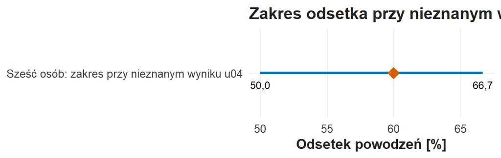

Zakres odsetka powodzeń sześciu osób przy nieznanym wyniku u04. Oś pozioma: odsetek powodzeń w procentach. Odcinek biegnie od 50,0% (u04 z niepowodzeniem) do 66,7% (u04 z powodzeniem); romb przy 60% oznacza odsetek wśród pięciu znanych wyników.

```r
zakres <- pokaz_wykres(wykres_zakresu)
print(zakres)
```

Wynik 60% opisuje pięć pomiarów małej próby dydaktycznej. Uogólnienie na użytkowników biblioteki wymaga projektu doboru próby i analizy niepewności, które wprowadzają wykład W03 (Losowość, estymacja) i ćwiczenie C05 (Niepewność estymaty).

## Średnia i mediana odpowiadają na różne pytania

Tabela podaje także medianę, czyli środkową wartość uporządkowanego zbioru. Uporządkowane ważne czasy wynoszą 5, 6, 8, 9 i 12 minut, więc dla $n=5$

$$\tilde{x}=x_{((n+1)/2)}=x_{(3)}=8 \text{ minut},$$

gdzie $x_{(k)}$ oznacza $k$-tą wartość po uporządkowaniu. Średnia również wynosi 8 minut i powstaje przez dzielenie sumy 40 przez 5.

Gdyby najdłuższy czas zmienił się z 12 na 22 minuty, średnia wzrosłaby do 10 minut, a mediana pozostałaby równa 8. Dlatego krótki opis zawsze nazywa miarę: „przeciętny czas” oznacza w różnych tekstach średnią albo medianę.

## Zapis wyniku według APA

Standard APA (*Publication Manual of the American Psychological Association*, 7. wydanie, 2020) porządkuje zapis wyników w naukach społecznych. Kurs stosuje cztery zasady APA w polskiej wersji: symbol statystyczny kursywą, po nim znak równości i wartość; średnia i mediana z dwoma miejscami po przecinku i jednostką; odsetek razem z licznikiem i mianownikiem; przecinek jako separator dziesiętny.

Zapis wyników opisowych według APA

| Wynik | Zapis APA | Przykład z tabeli `mini` |
| --- | --- | --- |
| Liczebność zbioru | *N* = liczba | *N* = 6 osób |
| Liczba ważnych pomiarów | *n* = liczba | *n* = 5 czasów |
| Średnia | *M* = wartość jednostka | *M* = 8,00 min |
| Mediana | *Mdn* = wartość jednostka | *Mdn* = 8,00 min |
| Zakres | minimum–maksimum jednostka | 5–12 min |
| Odsetek | *k* z *n* (odsetek) | 3 z 5 (60%) |

**Wzorzec opisu tabeli (APA).** Akapit zaczyna od liczebności, podaje miary czasu, potem wynik zadania, a kończy granicą opisu:

> W tabeli `mini` zarejestrowano czas pięciu z sześciu osób (*N* = 6, *n* = 5). Średni czas wyszukiwania wyniósł *M* = 8,00 min (*Mdn* = 8,00 min, zakres 5–12 min). Zadanie zakończyło się sukcesem u 3 z 5 osób ze znanym wynikiem (60%); czas i wynik osoby u04 pozostają nieznane. Opis dotyczy małej próby syntetycznej.

# LEARN 5: wykres opisujemy słowami

Wykres „Pięć zmierzonych czasów” ma na osi poziomej identyfikatory osób w kolejności alfabetycznej, a na osi pionowej czas w minutach. Każda osoba z zapisanym czasem to jeden punkt; przerywana linia przedstawia średnią 8 minut. Osoba u04 ma nieznany czas, więc wykres zawiera pięć punktów.

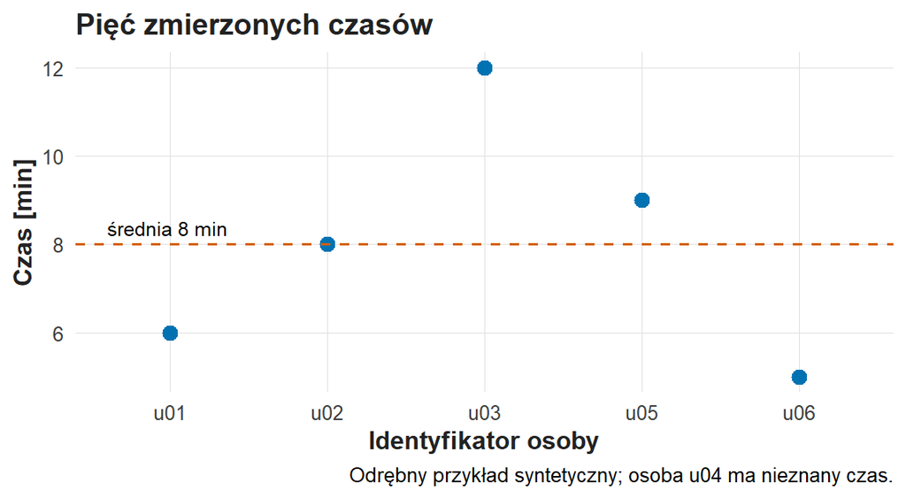

Pięć zmierzonych czasów tabeli mini. Oś pozioma: identyfikatory u01, u02, u03, u05, u06; oś pionowa: czas w minutach. Punkty leżą przy 6, 8, 12, 9 i 5 minutach; przerywana linia średniej przebiega przy 8 minutach.

```r
czasy_osob <- pokaz_wykres(wykres_mini)
print(czasy_osob)
```

Najkrótszy czas, 5 minut, ma osoba u06, a najdłuższy, 12 minut, osoba u03. Położenie punktu opisuje czas jednego zadania; ocena kompetencji wymaga innych zadań, kryteriów poprawności i szerszego pomiaru.

**Wzorzec opisu wykresu (APA).** Opis podaje zakres, średnią z *n* i osoby na krańcach:

> Pięć zarejestrowanych czasów mieściło się w zakresie 5–12 min (*M* = 8,00 min, *n* = 5); najkrócej szukała osoba u06 (5 min), a najdłużej osoba u03 (12 min).

Średnia jest wartością obliczoną: przy czasach 5 i 6 minut wynosi 5,5 minuty, czyli wartość leżącą między dwoma zmierzonymi czasami. W tabeli `mini` średnia 8 minut przypadkowo pokrywa się z czasem osoby u02. Statystyka opisuje zbiór.

Przyczyny długiego czasu leżą poza wykresem: sprawdzanie kilku wydań, wolne łącze albo inne rozumienie polecenia. Dobre zdanie opisowe nazywa wzorzec obecny w danych, a wyjaśnienie mechanizmu wymaga kolejnych danych.

## Jak z wyniku powstaje zdanie

Dobre zdanie pozwala drugiej osobie odnaleźć liczbę i sprawdzić jej znaczenie. Zapis „średnia czasu w pięciu ważnych pomiarach tabeli `mini` wyniosła 8 minut” podaje miarę, dane, liczebność i jednostkę.

| Wersja robocza | Element wymagający doprecyzowania | Wersja z uzasadnieniem |
| --- | --- | --- |
| „Badani mieli wynik 60” | Liczba osób czy procent? | „Trzy z pięciu znanych wyników były powodzeniami: 60%” |
| „u04 wyszukiwała 0 minut” | Brak zamieniono w pomiar | „Dla u04 czas pozostaje nieznany” |
| „Doświadczeni są wolniejsi” | Uogólnienie z małej demonstracji | „Porównanie grup wymaga osobnych średnich i liczebności” |
| „W tabeli jest sześć osób, więc N = 6” | Mianownik zależy od zmiennej | „Sześć rekordów, pięć ważnych czasów” |
| „Wykres udowadnia brak kompetencji” | Zmieniono konstrukt | „Wykres przedstawia zróżnicowanie czasu konkretnego zadania” |

Poprawa interpretacji polega często na zwężeniu zdania do mierzonej wielkości: czas jednego zadania, ocena użyteczności. Szersza nazwa, np. „kompetencja”, wymaga szerszego pomiaru.

Ćwiczenie C01 opisuje małą tabelę; wartość p i przedział ufności wprowadzają wykład W03 i ćwiczenie C05. Język wypracowany na C01 — miara, jednostka, mianownik — pozwala później odróżnić estymatę, statystykę testową i niepewność.

## Łączymy wykres z obserwacją

Najkrótszy czas ma osoba u06: 5 minut i niepowodzenie. Osoba u01 pracowała 6 minut i odniosła sukces. Krótszy czas i sukces opisują dwie różne cechy wykonania: u06 zakończyła próbę szybciej od u01, a właściwy dokument znalazła u01.

Deklarację odczytujemy analogicznie. Gdy ktoś wybiera 5 na skali pewności, a obserwowane zadanie kończy się niepowodzeniem, obie wartości są poprawnie zapisane: deklaracja dotyczy oceny własnej, obserwacja — wyniku konkretnej próby. Rekord z wysoką deklaracją i niepowodzeniem zostaje w danych jako informacja o relacji deklaracji i wykonania. Część CHALLENGE stosuje rozróżnienie deklaracji i obserwacji do portalu studenckiego.

**Wzorzec porównania dwóch rekordów.** Zdanie zestawia dwie osoby tymi samymi informacjami i nazywa, co je różni:

> Osoba u06 zakończyła zadanie po 5 min niepowodzeniem, a osoba u01 po 6 min sukcesem; krótszy czas u06 szedł w parze z niepoprawnym wynikiem.

**Wzorzec zestawienia deklaracji i obserwacji.**

> Osoba zadeklarowała pewność 5 w skali 1–5, a obserwowane zadanie zakończyła niepowodzeniem po 9 min; deklaracja i wynik zadania opisują dwie różne informacje o tej osobie.

# CHALLENGE — samodzielny opis portalu

W nowym scenariuszu osiem hipotetycznych osób szuka terminu składania wniosku w portalu studenckim. Obserwator zapisuje czas szukania i to, czy osoba znalazła poprawny termin; po zadaniu każda osoba deklaruje na skali 1–5 pewność, że potrafi korzystać z portalu. Liczby odczytujesz z tabel portalu, a sposób zapisu — z wzorców LEARN.

Każde z pięciu zadań ma ten sam układ:

1. **Zadanie** — jedno zdanie z przedmiotem opisu.
2. **Blok R** — uruchom go; wynik zawiera wszystkie liczby potrzebne do odpowiedzi.
3. **Wskazówki** — gdzie w wyniku szukać informacji, jak ją nazwać i wzór zdania do uzupełnienia.
4. **W akapicie wymagane** — elementy, które sprawdza prowadzący.
5. **Twój akapit** — pole odpowiedzi w ramce: znacznik w nawiasie kwadratowym zastępujesz własnym tekstem, a linie komentarza nad nim i pod nim pozostawiasz bez zmian.

Akapit liczy 3–5 zdań zwykłego tekstu, bez kodu R. Liczby przepisujesz z wyniku bloku, z jednostką i mianownikiem.

## CHALLENGE 1: Rekord osoby p06

**Zadanie:** opisz osobę p06 trzema wynikami — czasem, sukcesem i pewnością — i wskaż dane potrzebne do oceny jej ogólnych kompetencji.

```r
obserwacje_portalu <- odczyt_portalu(numer = 6)
print(obserwacje_portalu)
```

**Portal studencki — osiem osób**

| id | rok | czas_min | sukces | pewnosc |
| --- | --- | --- | --- | --- |
| p01 | pierwszy | 4 | 1 | 4 |
| p02 | pierwszy | 7 | 1 | 5 |
| p03 | kolejny | 11 | 0 | 4 |
| p04 | pierwszy | NA | NA | 3 |
| p05 | kolejny | 6 | 1 | 2 |
| p06 | kolejny | 14 | 0 | 5 |
| p07 | pierwszy | 9 | 1 | 4 |
| p08 | kolejny | 5 | 1 | 3 |

**Źródło informacji w kolumnach**

| Kolumna | Znaczenie | Źródło |
| --- | --- | --- |
| id | Identyfikator osoby | rejestr |
| rok | Rok studiów | cecha osoby |
| czas_min | Czas szukania terminu [min] | obserwacja |
| sukces | 1 = poprawny termin, 0 = niepoprawny termin | obserwacja |
| pewnosc | Pewność korzystania z portalu, 1–5 | deklaracja osoby |

**Rekord wybranej osoby**

| pole | wartosc |
| --- | --- |
| id | p06 |
| rok | kolejny |
| czas_min | 14 |
| sukces | 0 |
| pewnosc | 5 |

Blok wyświetla trzy tabele: „Portal studencki — osiem osób”, „Źródło informacji w kolumnach” i „Rekord wybranej osoby” z wartościami p06 w postaci „pole — wartość”.

*Wskazówki:*

- Rekord czytaj wiersz po wierszu: każde pole to jedna informacja o tej samej osobie.
- Tabela „Źródło informacji w kolumnach” mówi, które pole jest cechą osoby (rok), obserwacją (czas, sukces), a które deklaracją osoby (pewność).
- Kod `sukces` ma znaczenie z definicji kolumny: 1 — poprawny termin, 0 — niepoprawny termin.
- Jedno zadanie w jednym serwisie to jedna próba. Ocena ogólnych kompetencji wymaga zadań innego rodzaju i o różnej trudności oraz kryterium poprawności każdego zadania.
- Wzór zdania: „Osoba [id] ([rok] rok studiów) szukała terminu przez [czas] min i zakończyła zadanie [wynik słownie] (kod [0 lub 1]); swoją pewność oceniła na [wartość] w skali 1–5”.

*W akapicie wymagane:* (i) czas p06 z jednostką; (ii) wynik zadania słownie i kodem; (iii) deklarowana pewność ze skalą; (iv) rozróżnienie deklaracji i obserwacji; (v) co najmniej jeden rodzaj dodatkowych danych do oceny kompetencji.

**Twój akapit S01.** Znacznik w nawiasie kwadratowym zastąp własnym tekstem.

[UZUPELNIJ_S01]

## CHALLENGE 2: Skąd pochodzi liczba

**Zadanie:** wyjaśnij dwa sposoby wskazania czasu trzeciej osoby, różnicę między liczbą wierszy a liczbą ważnych czasów oraz miejsca kodu, wyniku i interpretacji w pliku.

```r
adresy <- tabela_adresow()
print(adresy)
```

**Polecenia wskazujące źródło wyniku**

| Wyrażenie R | Wynik |
| --- | --- |
| portal$czas_min[3] | 11 |
| portal[3, “czas_min”] | 11 |
| nrow(portal) | 8 |
| sum(!is.na(portal$czas_min)) | 7 |
| portal$id[is.na(portal$czas_min)] | p04 |

**Znaki w wyrażeniach R**

| Znak | Znaczenie |
| --- | --- |
| [3] | Trzecia pozycja wektora |
| [3, “czas_min”] | Wiersz 3 (przed przecinkiem), kolumna czas_min (po przecinku) |
| $ | Kolumna tabeli wybrana po nazwie |
| nrow() | Liczba wierszy tabeli, także z brakami |
| is.na() | TRUE dla brakującej wartości |
| ! | Zaprzeczenie: !is.na() daje TRUE dla wartości ważnej |

Blok wyświetla tabelę „Polecenia wskazujące źródło wyniku” (wyrażenie R i jego wynik) oraz tabelę „Znaki w wyrażeniach R” ze znaczeniem każdego znaku.

*Wskazówki:*

- Wyrażenie `portal$czas_min[3]` czytaj od lewej: tabela `portal`, kolumna `czas_min`, trzecia pozycja.
- W wyrażeniu `portal[3, "czas_min"]` liczba przed przecinkiem wskazuje wiersz, a nazwa po przecinku — kolumnę.
- `nrow(portal)` liczy wszystkie wiersze, także z brakiem; `sum(!is.na(portal$czas_min))` liczy ważne czasy. Ostatni wiersz tabeli wskazuje osobę, która różnicuje obie liczby.
- Na stronie zadania są trzy miejsca: szary blok z poleceniem, wynik pod blokiem i pole „Twój akapit”. Polecenia zapisują trwale pliki `zadanie.Rmd` i `analiza.R`.
- Wzór zdania: „Wyrażenia [pierwsze] i [drugie] wskazują czas osoby z trzeciego wiersza i zwracają [wartość] min; pierwsze wybiera […], drugie […]”.

*W akapicie wymagane:* (i) oba wyrażenia i wspólny wynik z jednostką; (ii) znaczenie nawiasu kwadratowego, przecinka i znaku `$`; (iii) liczba wierszy i liczba ważnych czasów z osobą, która je różnicuje; (iv) miejsce kodu, wyniku i interpretacji.

**Twój akapit S02.** Znacznik w nawiasie kwadratowym zastąp własnym tekstem.

[UZUPELNIJ_S02]

## CHALLENGE 3: Brak czy zero

Osoba przygotowująca raport proponuje wpisać zero w każdym rekordzie z brakującym czasem i uzasadnia propozycję argumentem: „wszyscy uczestnicy zostaną w analizie”.

**Zadanie:** oceń propozycję na podstawie jej skutku dla średniej i znaczenia pomiaru.

```r
warianty <- brak_portalu()
print(warianty)
```

**Dwie reguły potraktowania braku**

| Reguła | N | Suma czasu [min] | Średnia [min] |
| --- | --- | --- | --- |
| Brak pozostaje brakiem | 7 | 56 | 8 |
| Brak zastąpiony zerem | 8 | 56 | 7 |

**Rekord osoby p04**

| pole | wartosc |
| --- | --- |
| id | p04 |
| rok | pierwszy |
| czas_min | NA |
| sukces | NA |
| pewnosc | 3 |

Blok wyświetla tabelę „Dwie reguły potraktowania braku” (N, suma czasu i średnia dla obu reguł) oraz tabelę „Rekord osoby p04”.

*Wskazówki:*

- Suma czasu jest w obu wierszach taka sama; zmienia się mianownik N. Średnia to suma podzielona przez liczbę ważnych pomiarów: $\bar{x}=\sum x_i/n$.
- Zero minut oznaczałoby natychmiastowe znalezienie terminu. Rekord p04 podaje, co wiadomo o osobie p04, a czego brakuje.
- Protokół obserwacji zapisuje przebieg próby, np. przerwanie pomiaru, problem techniczny albo rezygnację. Zastanów się, który zapis wyjaśniłby brak czasu p04.
- Wzór zdania (APA): „Średni czas wyszukiwania wyniósł *M* = [wartość] min (*n* = [liczba]); czas osoby p04 pozostaje nieznany”.

*W akapicie wymagane:* (i) obie średnie z N; (ii) wybór reguły opisującej obecne dane z uzasadnieniem; (iii) jedna informacja, której należy szukać w protokole osoby p04.

**Twój akapit S03.** Znacznik w nawiasie kwadratowym zastąp własnym tekstem.

[UZUPELNIJ_S03]

## CHALLENGE 4: Informacja dla opiekuna portalu

Opiekun portalu potrzebuje dwóch informacji: ile trwało szukanie terminu i jak często znaleziono poprawny termin.

**Zadanie:** napisz opis próby w stylu APA z liczbą braków i jednym ograniczeniem.

```r
podsumowanie <- opis_portalu_do_raportu()
print(podsumowanie)
```

**Opis portalu studenckiego**

| Wskaźnik | Wartość |
| --- | --- |
| Wiersze | 8 |
| Ważny czas | 7 |
| Brak czasu | 1 |
| Średnia czasu [min] | 8,00 |
| Mediana czasu [min] | 7,00 |
| Ważny sukces | 7 |
| Sukcesy | 5 |
| Sukces [% ważnych] | 71,4 |

Blok wyświetla tabelę „Opis portalu studenckiego” z ośmioma wskaźnikami: liczbą wierszy, liczbą ważnych czasów i braków, średnią i medianą czasu, liczbą znanych wyników, liczbą sukcesów i odsetkiem sukcesów.

*Wskazówki:*

- Każda miara ma własny mianownik: czas — ważne czasy, sukces — znane wyniki zadania.
- Średnia dzieli sumę czasu przez liczbę ważnych pomiarów; mediana to środkowa wartość uporządkowanych czasów.
- Odsetek podajesz razem z licznikiem i mianownikiem: „[k] z [n] ([odsetek]%)”.
- Ograniczenie: w próbie siedmiu znanych wyników zmiana wyniku jednej osoby przesuwa odsetek o $100\%/7 \approx 14$ punktów procentowych.
- Wzorzec (APA): „W portalu zarejestrowano czas [n] z [N] osób (*N* = [..], *n* = [..]). Średni czas wyszukiwania wyniósł *M* = [..] min (*Mdn* = [..] min). Poprawny termin znalazło [k] z [n] osób ze znanym wynikiem ([..]%)”.

*W akapicie wymagane:* (i) N rekordów i *n* ważnych czasów; (ii) *M* i *Mdn* z jednostką; (iii) liczba sukcesów i odsetek z mianownikiem; (iv) jedno ograniczenie wynikające z małej syntetycznej próby.

**Twój akapit S04.** Znacznik w nawiasie kwadratowym zastąp własnym tekstem.

[UZUPELNIJ_S04]

## CHALLENGE 5: Deklaracja i obserwacja

W szkicu raportu pojawia się zdanie: „osoby pewne swoich umiejętności zawsze szybciej znajdują właściwą informację”.

**Zadanie:** porównaj dwie osoby pod względem deklaracji i obserwacji, popraw zdanie ze szkicu i zaproponuj dodatkowy pomiar.

```r
deklaracja_i_czas <- deklaracja_i_wynik()
print(deklaracja_i_czas)
```

**Osoby według deklarowanej pewności**

| Osoba | Pewność [1–5] | Czas [min] | Wynik zadania |
| --- | --- | --- | --- |
| p02 | 5 | 7 | sukces |
| p06 | 5 | 14 | niepowodzenie |
| p01 | 4 | 4 | sukces |
| p07 | 4 | 9 | sukces |
| p03 | 4 | 11 | niepowodzenie |
| p08 | 3 | 5 | sukces |
| p04 | 3 | NA | nieznany |
| p05 | 2 | 6 | sukces |

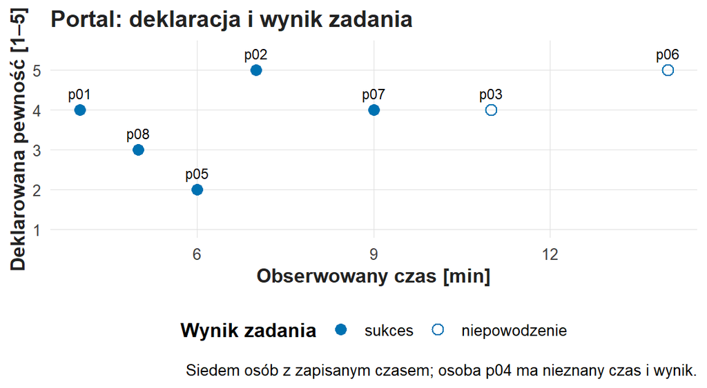

Portal: deklaracja i wynik zadania. Oś pozioma: obserwowany czas w minutach; oś pionowa: deklarowana pewność 1–5. Każdy punkt ma identyfikator osoby; koło pełne oznacza sukces, koło puste niepowodzenie. Osoba p04 ma nieznany czas.

Blok wyświetla tabelę „Osoby według deklarowanej pewności” (pewność, czas i wynik zadania każdej osoby, od najwyższej pewności) oraz wykres „Portal: deklaracja i wynik zadania” z tymi samymi osobami.

*Wskazówki:*

- W tabeli osoby o tej samej pewności stoją obok siebie; porównaj ich czas i wynik zadania.
- Na wykresie oś pozioma to czas, oś pionowa — pewność; koło pełne oznacza sukces, koło puste niepowodzenie.
- Zdanie ze szkicu zawiera słowo „zawsze”, więc jeden rekord wystarcza do jego sprawdzenia. Poprawione zdanie opisuje osoby z próby portalu.
- Dodatkowy pomiar pozwala ocenić trafność deklaracji, np. kilka zadań o różnej trudności albo pomiar pewności przed zadaniem.
- Wzór zdania: „Osoba [id] zadeklarowała pewność [wartość] i szukała [czas] min, kończąc zadanie [wynikiem], a osoba [id] przy pewności [wartość] szukała [czas] min, kończąc zadanie [wynikiem]”.

*W akapicie wymagane:* (i) dwa rekordy z pewnością, czasem i wynikiem; (ii) poprawione zdanie ze szkicu; (iii) jeden dodatkowy pomiar do przyszłego badania.

**Twój akapit S05.** Znacznik w nawiasie kwadratowym zastąp własnym tekstem.

[UZUPELNIJ_S05]

# Zapis i oddanie

Sprawdź pięć własnych akapitów w CHALLENGE: nazwę miary, liczbę, jednostkę i mianownik. Zapisz plik `zadanie.Rmd` w edytorze (Ctrl+S). Funkcja oddania tworzy PDF z zapisanego pliku.

W konsoli wykonaj jedno polecenie. Funkcja oddania tworzy aktualny PDF, sprawdza kompletność, otwiera PDF do obejrzenia i po potwierdzeniu literą `t` wysyła go do folderu zadania prowadzącego na serwerze UJ (nc.uj.edu.pl). Nazwa pliku zawiera Twoje ID oraz nazwisko i imię.

```r
oddaj_zadanie("Z01")
```

Oddanie potwierdza komunikat z nazwą wysłanego pliku, folderem i czasem; plik `oddania.csv` w folderze `moje-badania` zapisuje także sumę SHA-256 wysłanego PDF. Po komunikacie błędu popraw wskazany problem, zapisz plik i ponownie wywołaj `oddaj_zadanie("Z01")`; nowa wersja trafia do folderu obok poprzedniej. Ocenę prowadzący przekazuje osobno.

Po potwierdzonym oddaniu możesz zamknąć projekt: Posit Cloud zachowuje folder `moje-badania` do kolejnych zajęć. Na komputerze współdzielonym wyloguj się z Posit Cloud w przeglądarce. Przy braku sieci PDF pozostaje w folderze zadania; wyślij go tym samym poleceniem po odzyskaniu połączenia, a gdy problem trwa, poproś prowadzącego o ustalenie sposobu dostarczenia pracy.

## Co jest oceniane

| Kryterium | Dowód w Twojej pracy | Odpowiedzi | Punkty |
| --- | --- | --- | --- |
| Z01.1 Odtwarzalna praca w jednym Rmd | Zapisany Rmd i PDF z wynikami gotowych chunków oraz pięcioma odpowiedziami poza kodem | S01–S05 | 3 |
| Z01.2 Odczyt rekordu, miar czasu i mianownika odsetka | Rekord p06, dwa adresy wartości, N osób i ważnych czasów, średnia, mediana, liczba i odsetek sukcesów z jednostkami i mianownikami | S01–S04 | 3 |
| Z01.3 Źródło wyniku i granice wniosku o zachowaniu | Kod, wynik i interpretacja rozdzielone; informacja o p04; porównanie dwóch rekordów i dodatkowy pomiar | S02, S03, S05 | 2 |
| Z01.4 Własne ID, pliki i potwierdzona oddana wersja | Metadane z własnym ID oraz potwierdzenie oddania z nazwą pliku i sumą SHA-256 | S01–S05 | 2 |

Punkty przyznaje się za odczyt i wyjaśnienie wyniku. Poziomy wykonania każdego kryterium opisuje rubryka Z01: na stronie kursu w dokumencie `rubryki/Z01.html`, a w konsoli R po poleceniu `rubryka("Z01")`.

# Rozwinięcia do powtórki — poza rdzeniem spotkania

Rozwinięcia stosują ten sam sposób odczytu do większych danych, jednostek i komunikatów R. Rozwinięcia służą powtórce i pozostają poza oceną.

## Podgląd pełnego badania S02

Zbiór S02 ma więcej rekordów i kolumn niż tabela `mini`, a pytania pozostają te same. Najpierw sprawdzamy rozmiar danych przed przygotowaniem i po zastosowaniu reguł. Tabela „Rozmiar pełnego zbioru” podaje trzy liczby: 150 rekordów surowych, 148 rekordów po usunięciu dwóch identycznych duplikatów i 17 kolumn.

```r
rozmiar <- pokaz_tabele(wynik_glowny, "Rozmiar pełnego zbioru")
print(rozmiar)
```

**Rozmiar pełnego zbioru**

| N_surowe | N_po | kolumny |
| --- | --- | --- |
| 150 | 148 | 17 |

Surowy plik ma 15 kolumn; skrypt przygotowania dodaje dwie kolumny pochodne: `liczba_pozycji` (liczba ważnych odpowiedzi na sześć pozycji ankiety) i `indeks` (średnia tych odpowiedzi po odwróceniu pozycji 3). Kolumny pochodne streszczają informację obecną w sześciu kolumnach pozycji. Zmniejszenie liczby rekordów ze 150 do 148 dotyczy kopii tych samych odpowiedzi; reguły przygotowania omawia ćwiczenie C02.

Tabela „Sześć pierwszych rekordów S02” zawiera identyfikator, grupę, czas i powodzenie sześciu pierwszych osób ze 148. Przeczytaj jeden rekord z czasem i wynikiem zadania, np. o001: osoba z grupy nowych szukała 12,1 minuty i zakończyła zadanie niepowodzeniem.

```r
rekordy <- podglad_badania()
print(rekordy)
```

**Sześć pierwszych rekordów S02**

| ID | Grupa | Czas [min] | Powodzenie |
| --- | --- | --- | --- |
| o001 | nowi | 12,1 | 0 |
| o002 | nowi | 10,4 | 1 |
| o003 | doświadczeni | 5,8 | 1 |
| o004 | doświadczeni | 16,1 | 1 |
| o005 | doświadczeni | 28,0 | 1 |
| o006 | doświadczeni | 6,3 | 0 |

Podgląd ma sześć wierszy, a pełna tabela 148. Polecenie `head()` ogranicza wydruk do sześciu pierwszych wierszy; obiekt zachowuje wszystkie rekordy, więc N analizy odczytujemy z tabeli rozmiaru.

Wykres „Czasy wszystkich osób S02” umieszcza każdy ważny czas na jednej osi; pionowe rozsunięcie punktów ułatwia odczyt powtarzających się wartości. Pionowe linie oznaczają pierwszy kwartyl, medianę i trzeci kwartyl, czyli granice ćwiartek uporządkowanych czasów.

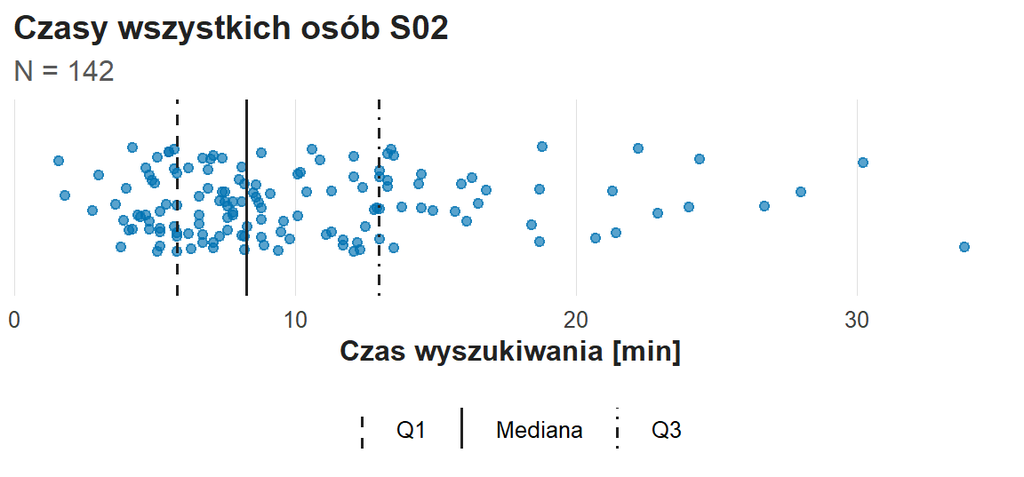

Czasy wszystkich osób S02 z ważnym pomiarem (N = 142). Oś pozioma: czas wyszukiwania w minutach. Połowa punktów leży między pierwszym kwartylem 5,8 minuty a trzecim kwartylem 13,0 minuty, mediana wynosi 8,25 minuty; prawy ogon sięga 33,8 minuty, a najkrótszy czas to 1,6 minuty.

```r
czasy_podgladu <- pokaz_wykres(wykres_glowny)
print(czasy_podgladu)
```

Wykres obejmuje 142 z 148 osób: sześć osób ma brak czasu. Połowa osób szukała od 5,8 do 13,0 minuty, a kilka osób ponad 25 minut. Ćwiczenie C03 (Portret próby) opisuje rozkład czasu S02 miarami i histogramem.

## Słownik jest częścią pełnych danych

Słownik nadaje kolumnom znaczenie: nazwa `powodzenie` wymaga informacji, kto ocenia wynik, a nazwa `czas_wyszukiwania` — informacji o jednostce. Tabela „Wybrane kolumny zbioru S02” podaje dla ośmiu kolumn opis, skalę pomiaru i kodowanie; jednostką czasu są minuty, a powodzenie ocenia obserwator.

```r
slownik <- slownik_pelnego_badania()
print(slownik)
```

Wybrane kolumny zbioru S02: opis, skala pomiaru i kodowanie

| Kolumna | Opis | Skala | Kodowanie |
| --- | --- | --- | --- |
| id_odpowiedzi | Identyfikator odpowiedzi; identyczne powtórzenie to duplikat | identyfikator | o001… |
| grupa | Grupa porównania | nominalna | nowi / doświadczeni |
| czestosc_korzystania | Częstość korzystania z zasobu | porządkowa | 1=nigdy; 2=rzadko; 3=czasami; 4=często; 5=bardzo często |
| czas_wyszukiwania | Obserwowany czas wykonania zadania wyszukiwawczego w minutach | ilorazowa | 0–120 minut; wartości poza zakresem wymagają oceny |
| pozycja_1 | Szybko znajduję pole wyszukiwania w katalogu. | porządkowa | 1–5: od 1 = zdecydowanie nie do 5 = zdecydowanie tak |
| pozycja_3 | Odczytanie rekordu wymaga ode mnie zgadywania. | porządkowa | 1–5: od 1 = zdecydowanie nie do 5 = zdecydowanie tak; pozycja odwrócona |
| powodzenie | Obserwowany wynik zadania: Czy udało się znaleźć wskazany dokument? | nominalna | 0=nie; 1=tak |
| kanal_1 | Wybrano kanał: strona WWW | nominalna | 0=nie wybrano; 1=wybrano |

Identyfikator służy odnajdywaniu i łączeniu rekordów. Grupa porównania jest kategorią. Czas ma jednostkę i naturalne zero. Pojedyncza odpowiedź 1–5 jest uporządkowana, a równość odległości między sąsiednimi kategoriami wymagałaby dodatkowego uzasadnienia.

Pełny scenariusz S02 zawiera sześć pozycji dotyczących użyteczności katalogu i radzenia sobie z nim. Skrypt C01 tworzy z nich kolumnę `indeks`, czyli dydaktyczny indeks deklarowanej użyteczności katalogu; ćwiczenie C04 (Od pozycji do konstruktu) omawia regułę indeksu i sprawdza, które pozycje dotyczą użytkownika, a które systemu.

Wartość pozycji ankiety pochodzi od uczestnika wybierającego odpowiedź, a czas i poprawność zadania — z obserwacji wykonania. Obie informacje mają zapis liczbowy i dwa źródła; słownik rozróżnia uczestnika i obserwatora jako źródła pomiaru.

## Trzy dodatkowe przykłady odczytu

### Przypadek A: ten sam wynik, dwa mianowniki

W ankiecie odpowiedziało dziesięć osób. Sześć wybrało „tak”, dwie „nie”, a dwie pominęły pytanie. Jaki odsetek ważnych odpowiedzi stanowi „tak”? Zatrzymaj się przed czytaniem rozwiązania i nazwij mianownik.

Wśród ośmiu ważnych odpowiedzi sześć to „tak”, czyli $6/8=75\%$. Zdanie „60% wszystkich dziesięciu respondentów zaznaczyło tak” ($6/10$) ma inny mianownik i wymaga informacji o dwóch brakach. Każda wersja podaje swój mianownik.

### Przypadek B: jednostka przesądza o znaczeniu

Tabela zawiera wartość 120 w kolumnie czasu. Jedna osoba odczytuje „dwie minuty”, druga „dwie godziny”. Słownik rozstrzyga spór: przy sekundach 120 to dwie minuty, przy minutach — dwie godziny.

Przed przeliczeniem jednostki sprawdzamy źródło, a po przeliczeniu zmieniamy podpis. Poprawka nietypowej wartości opiera się na źródle danych; reguły poprawek omawia ćwiczenie C02.

### Przypadek C: deklaracja i wykonanie

Osoba wybiera odpowiedź 5 na stwierdzenie „łatwo znajduję potrzebny dokument”, a obserwowane zadanie kończy się niepowodzeniem. Wiersz zostaje w danych: deklaracja i wykonanie odnoszą się do różnych informacji i mogą się rozchodzić.

Taki rekord jest szczególnie interesujący dla pytania o samoocenę. Ocena przeszacowania umiejętności wymaga wielu zadań: pojedynczy wynik mógł zależeć od nietypowego zadania, niejasnego polecenia albo przypadku. Ćwiczenie C08 (Samoocena a wykonanie) bada związek obu rodzajów pomiaru na poziomie całej próby.

## Powrót po zajęciach: czytanie komunikatów

Komunikat błędu opisuje przerwane polecenie i dotyczy kodu. Najpierw sprawdź ostatnie uruchomione polecenie, nazwę obiektu i katalog pracy. Zmieniaj jedną rzecz naraz i uruchamiaj ponownie, aby wiedzieć, która zmiana pomogła.

| Objaw | Możliwe znaczenie | Pierwszy krok |
| --- | --- | --- |
| `object ... not found` | Obiekt powstaje po uruchomieniu chunka `przygotowanie` albo nazwa ma literówkę | Uruchom chunk `przygotowanie` i porównaj nazwę |
| `cannot open file` | Program szuka pliku pod błędną ścieżką | Sprawdź katalog pracy i istnienie pliku |
| Średnia wynosi `NA` | Obliczenie objęło brak | Sprawdź braki i regułę ich obsługi |
| Wynik różni się od PDF | Inne dane, parametry lub starszy dokument | Porównaj wariant i uruchom analizę od początku |
| W konsoli pojawia się `+` | Polecenie czeka na domknięcie | Przerwij klawiszem Esc i sprawdź nawias lub cudzysłów |
| Wysyłka kończy się bez potwierdzenia | Praca jest zapisana lokalnie | Sprawdź status i zachowaj pliki |

Wynik `NA` oznacza, że obliczenie objęło brak, i dotyczy polecenia, a liczbowy wynik wymaga dalej sprawdzenia kodowania kolumny: program poprawnie policzy średnią także dla źle zakodowanej kolumny.

Tabela „Polecenie i jego sens” zestawia składnię potrzebną do odczytu z krótkim opisem każdego polecenia. Potraktuj tabelę jak słownik poleceń. Wyjaśnij słowami dwa wybrane wiersze, odwołując się do tabeli `mini`.

```r
polecenia <- slownik_odczytu()
print(polecenia)
```

**Polecenie i jego sens**

| polecenie | sens |
| --- | --- |
| czasy[3] | Trzecia wartość wektora |
| mini[3, “czas_min”] | Czas z trzeciego wiersza tabeli |
| mini$czas_min | Cała kolumna czasu |
| nrow(mini) | Liczba wierszy, także z brakami |
| sum(is.na(czasy)) | Liczba braków czasu |
| mean(czasy, na.rm = TRUE) | Średnia wyłącznie zmierzonych czasów |

## Instalacja w Posit Cloud i na własnym komputerze

Instalacja to jednorazowy krok przed pracą, w projekcie Posit Cloud albo w RStudio na własnym komputerze. Projekt kursu udostępniony przez prowadzącego w Posit Cloud ma pakiet już zainstalowany. Po instalacji otwierasz własny katalog pracy funkcją `rozpocznij_zajecia()`.

Pierwsze polecenie z następnego bloku instaluje pakiet kursu razem ze wszystkimi pakietami używanymi w ćwiczeniach, a drugie przygotowuje narzędzia PDF (TinyTeX). Instalacja wymaga sieci i trwa kilka minut, a późniejszy odczyt lokalnych PDF i HTML działa bez internetu. Wersję pakietu dla rocznika podaje strona kursu.

```r
install.packages("badaniaZI", repos = c(
  "https://marekdejauj.github.io/projektowanie-badan-ZI/pakiet",
  getOption("repos")
))
badaniaZI::przygotuj_pdf()
```

PDF Twojej pracy powstaje z uzupełnionego Rmd. Funkcja `przygotuj_pdf()` instaluje LaTeX potrzebny do PDF i składa próbny dokument. Problem techniczny zgłoś prowadzącemu; zadanie pisemne pozostaje pisemne.

## Samokontrola: od liczby w raporcie do osoby w tabeli

Po kilku dniach inna osoba czyta Twoją odpowiedź i pyta: „Skąd wiadomo, że osiem minut dotyczy zadania wyszukiwania w tabeli `mini`?”. Odpowiedź wskazuje łańcuch od pytania, przez kolumnę i regułę obliczenia, do zapisanej tabeli wyniku.

W tabeli `mini` łańcuch przechodzi się w obie strony. Pytanie dotyczy średniego zarejestrowanego czasu. Kolumna `czas_min` zawiera sześć miejsc, w tym jeden brak. Wektor ważnych wartości obejmuje 6, 8, 12, 9 i 5 minut. Suma wynosi 40, mianownik 5, wynik 8 minut. Nazwa miary w raporcie wskazuje operację: sumę 40 minut podzieloną przez 5 ważnych pomiarów.

W większym zbiorze ręczne sprawdzanie każdej sumy zastępuje ta sama struktura dowodu: słownik objaśnia kolumnę, skrypt zapisuje regułę, a tabela podaje wynik i liczebność. Zdanie jest sprawdzalne, gdy łańcuch zawiera słownik, skrypt i tabelę wyniku.

| Element zdania | Miejsce sprawdzenia | Pytanie kontrolne |
| --- | --- | --- |
| „czas wykonania” | Słownik i protokół | Czy to czas do zakończenia, czy do ostatniego kliknięcia? |
| „średni” | Reguła podsumowania | Czy wynik pochodzi ze średniej, czy z mediany? |
| „w pięciu pomiarach” | Licznik ważnych wartości | Czy brak pominięto wyłącznie w obliczeniu średniej? |
| „osiem minut” | Tabela wyniku i jednostka | Czy podpis minut odpowiada zapisanym wartościom? |
| „w tej próbie” | Definicja zbioru | Czy zdanie obejmuje wyłącznie zbadane osoby? |

Każda liczba w raporcie ma wskazane źródło, jednostkę i zakres analizy. Zdanie oparte na tabeli lub słowniku odróżnia odczyt danych od dopowiedzianego wyjaśnienia.

### Dwie tabele z takim samym procentem

Wyobraź sobie dwa odrębne badania próbne. W pierwszym sukces odniosły cztery z pięciu osób, w drugim czterdzieści z pięćdziesięciu. W obu proporcja wynosi 0,8, czyli 80%. Odsetek jest ten sam, a ilość informacji różna: 5 i 50 osób.

Zmiana wyniku jednej osoby przesuwa odsetek o $100\%/n$:

$$\Delta_{\text{jednej osoby}}=\frac{100\%}{n}: \qquad \frac{100\%}{5}=20 \text{ punktów procentowych}, \qquad \frac{100\%}{50}=2 \text{ punkty procentowe}.$$

Wykres „Wrażliwość odsetka na jedną osobę” przedstawia oba badania. N jest więc częścią wyniku, choć definicja proporcji pozostaje ta sama.

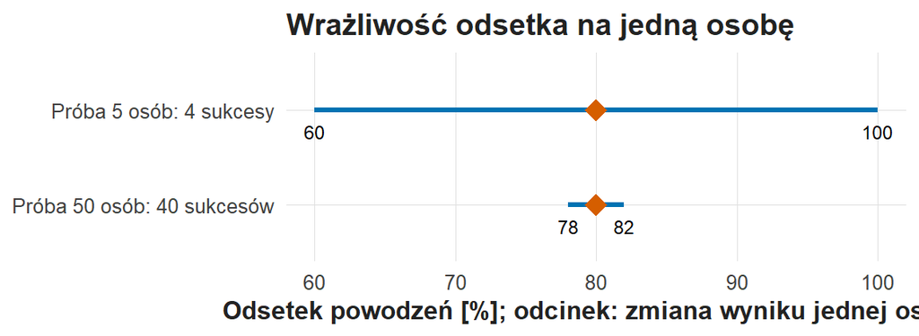

Wrażliwość odsetka na wynik jednej osoby. Oś pozioma: odsetek powodzeń w procentach. W próbie 5 osób romb przy 80% i odcinek od 60% do 100%: zmiana wyniku jednej osoby przesuwa odsetek o 20 punktów procentowych; w próbie 50 osób odcinek od 78% do 82%, czyli o 2 punkty procentowe.

```r
czulosc <- pokaz_wykres(wykres_czulosci)
print(czulosc)
```

Liczba osób i sposób ich doboru odpowiadają na dwa różne pytania. Pięćdziesiąt osób zrekrutowanych na szkoleniu bibliotecznym opisuje uczestników szkoleń. Wykład W03 łączy wrażliwość na liczebność z formalnym językiem niepewności.

### Punkty procentowe a procentowa zmiana

Wzrost odsetka powodzeń z 50% do 60% to różnica 10 punktów procentowych i wzrost względny o 20%:

$$\Delta_{pp}=p_2-p_1=60\%-50\%=10 \text{ pp},
\qquad
\Delta_{\text{wzgl}}=\frac{p_2-p_1}{p_1}=\frac{10}{50}=20\% .$$

Symbol $p_1$ oznacza odsetek wyjściowy, a $p_2$ odsetek po zmianie. W raporcie o usłudze zdanie „skuteczność zwiększyła się o 10%” wymaga doprecyzowania: przy wyjściowych 50% wzrost względny o 10% prowadzi do 55%, a wzrost o 10 punktów procentowych — do 60%.

Raport najpierw podaje oba odsetki i ich mianowniki, a potem wybraną miarę porównania. Poprawny odczyt języka procentów wymaga wiedzy, która liczba jest podstawą dzielenia.

### Krótka próba redakcyjna

Popraw zdanie: „Komputer pokazał 0,8, więc osiemdziesięciu studentów umie wyszukiwać”. Pierwszy problem to zamiana proporcji w liczbę osób. Drugi to rozszerzenie wyniku pojedynczego zadania na całą umiejętność. Trzeci to pominięcie liczebności i statusu danych.

Poprawa dla przykładu czterech z pięciu osób brzmi: „W odrębnej próbie dydaktycznej cztery z pięciu osób wykonały zadanie poprawnie, co stanowi 80% znanych wyników”. Zdanie dotyczy jednego zadania. Przy brakach raport podaje dodatkowo ich liczbę.

Porównaj poprawioną wersję z własną odpowiedzią Z01. Sprawdź, czy odpowiedź przechodzi od wartości technicznej wprost do szerokiej diagnozy. Na pierwszych zajęciach rozpoznanie przeskoku od wartości technicznej do diagnozy waży więcej niż uruchomienie większej liczby funkcji.

Wyjaśnij pięć zasad: „jeden wiersz to jedna osoba”, „mianownik to liczba ważnych wartości zmiennej”, „NA oznacza brak pomiaru”, „konstrukt definiują słownik i protokół” oraz „każdy wynik ma zapisane źródło”. Do każdej zasady podaj przykład z ćwiczenia C01.

Pięć zasad przygotowuje do ćwiczenia C02 (Surowy eksport). Surowy eksport zawiera duplikaty, kody braków i wartości wymagające sprawdzenia, a pytanie przewodnie C02 brzmi: jak decyzja porządkowania zmienia informację o badanych osobach?

## Kontekst badawczy

Łączenie ankiety z obserwacją działania nawiązuje do podejścia opisanego przez [Hargittai (2002)](https://webuse.org/p/a09/). Tabela `mini` i zbiór S02 pozostają niezależnymi przykładami syntetycznymi. Pozytywna ocena usługi, deklarowana umiejętność i poprawne wykonanie zadania mają odrębne znaczenia; ich relację badają kolejne ćwiczenia.